# IC11-2 Case 31: Summary of Data Analysis

R1, R2, R5, and R6 | Employees Federal Credit Union

Danielle Meza

Cal Poly Pomona

2026-11-08

# Introduction

## Purpose of This Report

- Employees Federal Credit Union (EFCU) wants to know why members are not borrowing from the credit union and how members view its operations.
- This report summarizes the analysis for four research questions:
  - **R1:** Why do people join the Credit Union?
  - **R2:** Why do members use other financial institutions when they need to borrow funds?
  - **R5:** How well are the members aware of the services offered by the credit union?
  - **R6:** What are the members’ attitudes and beliefs about how effectively the credit union is operated?
- Data: 128 survey respondents (mail survey, simple random sample of 300 members).

## Data Analysis Plan

| RQ | Variables | Scale | Test |
| --- | --- | --- | --- |
| R1 | q7r (savings rates) | Interval | Descriptives, one-sample t-test (μ = 3) |
| R2 | q8r (loan rates), q30 (CU rates lower than others) | Interval | Descriptives, one-sample t-test (μ = 3) |
| R5 | q13r to q26r (awareness of 14 services) | Ordinal | Frequency table, mode, median, chi-square goodness of fit |
| R6 | q9r, q11, q12rc | Nominal | Descriptives, chi-square goodness of fit |
| R6 | q10r | Interval (4-point) | One-sample t-test (μ = 2.5) |
| R6 | q31 to q34, q37r | Interval | One-sample t-tests (μ = 3), one per item |

## Data Preparation

I used the cleaned file I created in the data preparation assignment (`Case 31 Data_efcu_1_DM_cleaned.sav`). It keeps `q7r`, `q8r`, `q10r`, and `q37r` reverse-coded so higher means better or higher. “No opinion” and “No answer” were already set to missing.

```r
library(tidyverse)
library(haven)
library(psych)
library(broom)
library(knitr)
theme_set(theme_minimal(base_size = 18))

case31 <- read_sav("Case 31 Data_efcu_1_DM_cleaned.sav") |>
  mutate(across(where(is.labelled), as.numeric))
dim(case31)
```

```
[1] 128  38
```

## Extra Recoding for R5 and R6

- **q13r to q26r:** awareness items flipped so the order runs Unaware < Aware but Have Not Used < Aware and Have Used.
- **q9r:** statement frequency collapsed into “About right” vs. “Not right”.
- **q11, q12rc:** Yes/No only. “No answer” is treated as missing.

```r
aw_levels <- c("Unaware", "Aware but Have Not Used", "Aware and Have Used")

case31 <- case31 |>
  mutate(
    across(q13:q26,
           \(x) factor(4 - x, levels = 1:3, labels = aw_levels, ordered = TRUE),
           .names = "{.col}r"),
    q9r = factor(if_else(q9 == 3, "About right", "Not right"),
                 levels = c("About right", "Not right")),
    q11 = factor(case_match(q11, 1 ~ "Yes", 2 ~ "No", .default = NA_character_),
                 levels = c("Yes", "No")),
    q12rc = factor(case_match(q12, 1 ~ "Yes", 2 ~ "No", .default = NA_character_),
                   levels = c("Yes", "No"))
  )
```

# R1: Why Do People Join the Credit Union?

## R1 Overview

- **Construct:** Opinion on the savings rate the credit union offers
- **Operationalization:** q7r (1 = Very Low … 5 = Very High)
- **Scale:** Interval (1 to 5 Likert-type)
- **Statistics:** Descriptive statistics, followed by a one-sample t-test

## R1: Descriptive Statistics

```r
case31 |>
  count(q7r) |>
  mutate(
    Opinion = c("Very Low", "Low", "Average", "High", "Very High")[q7r] |> replace_na("Missing"),
    Percent = round(100 * n / sum(n), 1)
  ) |>
  select(Opinion, n, Percent) |>
  kable()
```

| Opinion | n | Percent |
| --- | --- | --- |
| Very Low | 1 | 0.8 |
| Low | 12 | 9.4 |
| Average | 83 | 64.8 |
| High | 22 | 17.2 |
| Missing | 10 | 7.8 |

```r
describe(case31$q7r) |> kable(digits = 2)
```

|  | vars | n | mean | sd | median | trimmed | mad | min | max | range | skew | kurtosis | se |
| --- | --- | --- | --- | --- | --- | --- | --- | --- | --- | --- | --- | --- | --- |
| X1 | 1 | 118 | 3.07 | 0.57 | 3 | 3.09 | 0 | 1 | 4 | 3 | -0.26 | 1.18 | 0.05 |

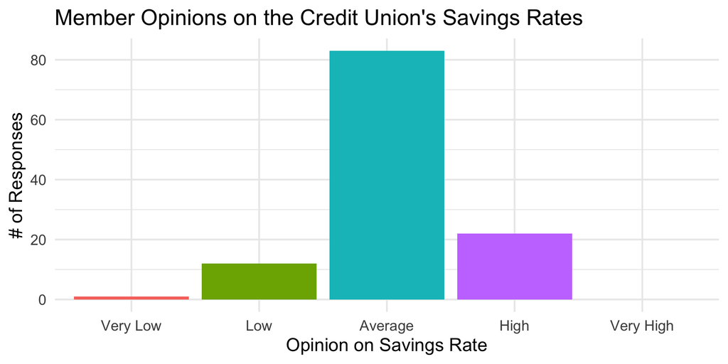

```r
case31 |>
  filter(!is.na(q7r)) |>
  mutate(q7r = factor(q7r, 1:5, c("Very Low", "Low", "Average", "High", "Very High"))) |>
  ggplot(aes(q7r, fill = q7r)) +
  geom_bar(show.legend = FALSE) +
  scale_x_discrete(drop = FALSE) +
  labs(x = "Opinion on Savings Rate", y = "# of Responses",
       title = "Member Opinions on the Credit Union's Savings Rates")
```

## R1: One-Sample t-Test

- $H_0: \mu = 3$ (members see the savings rate as “average”)
- $H_A: \mu \neq 3$

```r
t.test(case31$q7r, mu = 3)
```

```
    One Sample t-test

data:  case31$q7r
t = 1.3016, df = 117, p-value = 0.1956
alternative hypothesis: true mean is not equal to 3
95 percent confidence interval:
 2.964639 3.170954
sample estimates:
mean of x
 3.067797
```

**Insights about R1**

- Most members (65% of all respondents, 70% of those who gave an opinion) say the savings rate is **average**.
- The sample mean is 3.07, which is not different from 3 (*p* = 0.196).
- Members see the credit union’s savings rate as about average. Savings rates do not stand out as a reason people join.

# R2: Why Do Members Borrow from Other Institutions?

## R2 Overview

- **Construct:** Reasons to borrow from other financial institutions
- **Operationalization:** q8r (opinion on loan rates) and q30 (agreement that CU’s rates are lower than other institutions)
- **Scale:** Interval (1 to 5 Likert-type)
- **Statistics:** Descriptive statistics, followed by one-sample t-tests ($H_0: \mu = 3$)

## R2: Descriptive Statistics

```r
bind_rows(
  describe(case31$q8r) |> mutate(item = "q8r: Loan rates (1 = Very Low, 5 = Very High)"),
  describe(case31$q30) |> mutate(item = "q30: CU rates lower than others (1 = Strongly Disagree, 5 = Strongly Agree)")
) |>
  select(item, n, mean, sd, median, min, max) |>
  kable(digits = 2)
```

|  | item | n | mean | sd | median | min | max |
| --- | --- | --- | --- | --- | --- | --- | --- |
| X1…1 | q8r: Loan rates (1 = Very Low, 5 = Very High) | 107 | 3.14 | 0.76 | 3 | 1 | 5 |
| X1…2 | q30: CU rates lower than others (1 = Strongly Disagree, 5 = Strongly Agree) | 128 | 3.06 | 0.87 | 3 | 1 | 5 |

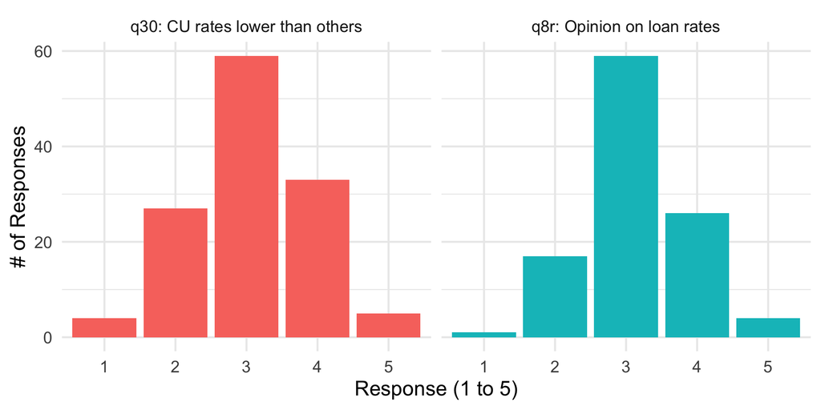

```r
case31 |>
  select(q8r, q30) |>
  pivot_longer(everything(), names_to = "item", values_to = "value") |>
  filter(!is.na(value)) |>
  ggplot(aes(factor(value), fill = item)) +
  geom_bar(show.legend = FALSE) +
  facet_wrap(~item, labeller = as_labeller(c(q8r = "q8r: Opinion on loan rates", q30 = "q30: CU rates lower than others"))) +
  labs(x = "Response (1 to 5)", y = "# of Responses")
```

## R2: One-Sample t-Tests

```r
bind_rows(
  tt(case31$q8r, 3, "q8r: Loan rates"),
  tt(case31$q30, 3, "q30: CU rates lower than others")
) |>
  mutate(p = fmt_p(p)) |>
  kable(digits = 2)
```

| Item | n | Mean | SD | Test value | t | df | p | 95% CI |
| --- | --- | --- | --- | --- | --- | --- | --- | --- |
| q8r: Loan rates | 107 | 3.14 | 0.76 | 3 | 1.91 | 106 | 0.058 | [2.99, 3.29] |
| q30: CU rates lower than others | 128 | 3.06 | 0.87 | 3 | 0.82 | 127 | 0.416 | [2.91, 3.21] |

**Insights about R2**

- Members’ opinion of the credit union’s loan rates (q8r, *M* = 3.14) is about average and only marginally above 3 (*p* = 0.058).
- Members neither agree nor disagree that CU rates are lower than competitors’ (q30, *M* = 3.06, *p* = 0.416).
- The credit union does not have a clear rate advantage in members’ minds. This may be one reason members look to other institutions when they borrow.
- **Limit:** The survey has no direct question on why members borrow elsewhere, so this is indirect evidence.

# R5: Awareness of Services

## R5 Overview

- **Construct:** Awareness of services offered by the credit union
- **Operationalization:** q13r to q26r (14 services)
- **Scale:** Ordinal (Unaware < Aware but Have Not Used < Aware and Have Used)
- **Statistics:** Frequency table, mode, median, chi-square goodness-of-fit test
  - $H_0$: members are equally spread across the three awareness levels (1/3 each)
  - $H_A$: the spread is not equal

## R5: Example, Regular Share Account (q13r)

```r
tab <- table(case31$q13r)
tab |> as.data.frame() |> rename(Awareness = Var1, n = Freq) |>
  mutate(Percent = round(100 * n / sum(n), 1)) |> kable()
```

| Awareness | n | Percent |
| --- | --- | --- |
| Unaware | 83 | 64.8 |
| Aware but Have Not Used | 32 | 25.0 |
| Aware and Have Used | 13 | 10.2 |

```r
chisq.test(tab, p = rep(1/3, 3))
```

```
    Chi-squared test for given probabilities

data:  tab
X-squared = 61.422, df = 2, p-value = 4.596e-14
```

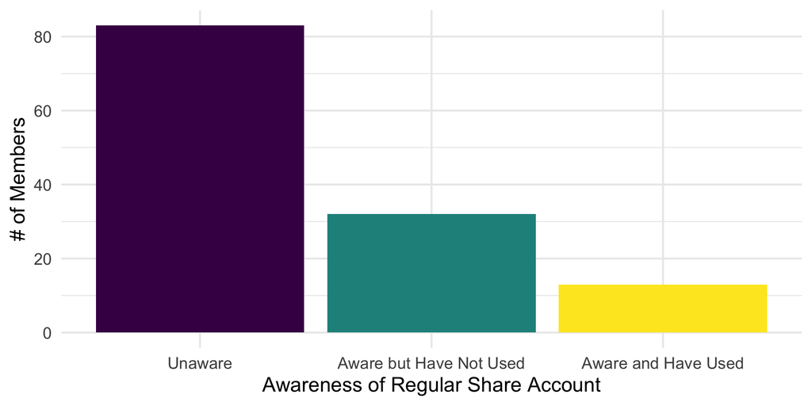

```r
case31 |>
  ggplot(aes(q13r, fill = q13r)) +
  geom_bar(show.legend = FALSE) +
  labs(x = "Awareness of Regular Share Account", y = "# of Members")
```

## R5: All 14 Services

```r
svc_names <- c(
  q13r = "Regular share account", q14r = "Special subaccounts", q15r = "Christmas club account",
  q16r = "IRA", q17r = "Master credit card", q18r = "Signature loans",
  q19r = "New car loans", q20r = "Late model car loans", q21r = "Older model car loans",
  q22r = "Household goods loans", q23r = "Recreational loans",
  q24r = "Share collateralized loan", q25r = "IRA loans", q26r = "Line of credit loans"
)

aw_long <- case31 |>
  select(q13r:q26r) |>
  pivot_longer(everything(), names_to = "item", values_to = "level")

aw_long |>
  count(item, level) |>
  group_by(item) |>
  mutate(pct = round(100 * n / sum(n))) |>
  ungroup() |>
  mutate(cell = paste0(n, " (", pct, "%)")) |>
  select(item, level, cell) |>
  pivot_wider(names_from = level, values_from = cell, values_fill = "0 (0%)") |>
  mutate(Service = svc_names[item], .before = 1) |>
  select(Service, all_of(aw_levels)) |>
  kable()
```

| Service | Unaware | Aware but Have Not Used | Aware and Have Used |
| --- | --- | --- | --- |
| Regular share account | 83 (65%) | 32 (25%) | 13 (10%) |
| Special subaccounts | 46 (36%) | 70 (55%) | 12 (9%) |
| Christmas club account | 42 (33%) | 75 (59%) | 11 (9%) |
| IRA | 35 (27%) | 64 (50%) | 29 (23%) |
| Master credit card | 15 (12%) | 57 (45%) | 56 (44%) |
| Signature loans | 5 (4%) | 104 (81%) | 19 (15%) |
| New car loans | 5 (4%) | 99 (77%) | 24 (19%) |
| Late model car loans | 12 (9%) | 102 (80%) | 14 (11%) |
| Older model car loans | 33 (26%) | 83 (65%) | 12 (9%) |
| Household goods loans | 37 (29%) | 80 (62%) | 11 (9%) |
| Recreational loans | 55 (43%) | 60 (47%) | 13 (10%) |
| Share collateralized loan | 69 (54%) | 57 (45%) | 2 (2%) |
| IRA loans | 78 (61%) | 46 (36%) | 4 (3%) |
| Line of credit loans | 0 (0%) | 80 (62%) | 48 (38%) |

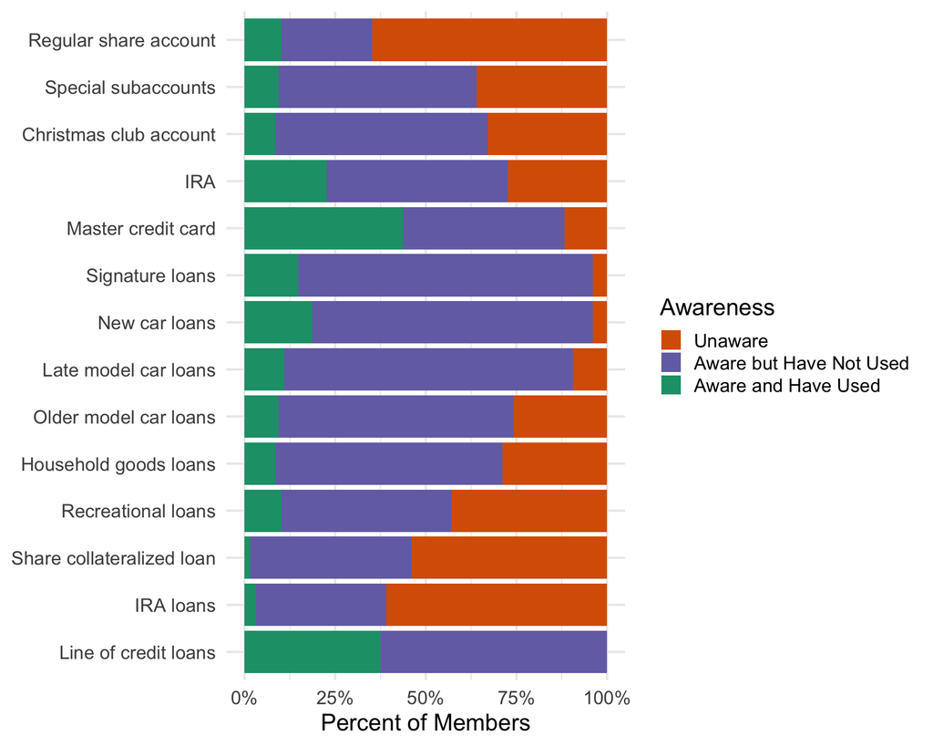

```r
aw_long |>
  mutate(Service = factor(svc_names[item], levels = rev(svc_names))) |>
  count(Service, level) |>
  ggplot(aes(n, Service, fill = level)) +
  geom_col(position = "fill") +
  scale_x_continuous(labels = scales::percent) +
  scale_fill_manual(values = c("#d95f02", "#7570b3", "#1b9e77")) +
  labs(x = "Percent of Members", y = NULL, fill = "Awareness")
```

## R5: Mode, Median, and Chi-Square Tests

```r
r5_tests <- map_dfr(names(svc_names), \(v) {
  x <- case31[[v]]
  ct <- chisq.test(table(x), p = rep(1/3, 3))
  tibble(
    Service = svc_names[[v]],
    Mode = names(which.max(table(x))),
    Median = levels(x)[median(as.numeric(x))],
    `Chi-square` = unname(ct$statistic),
    df = unname(ct$parameter),
    p = fmt_p(ct$p.value)
  )
})
r5_tests |> kable(digits = 1)
```

| Service | Mode | Median | Chi-square | df | p |
| --- | --- | --- | --- | --- | --- |
| Regular share account | Unaware | Unaware | 61.4 | 2 | < .001 |
| Special subaccounts | Aware but Have Not Used | Aware but Have Not Used | 39.8 | 2 | < .001 |
| Christmas club account | Aware but Have Not Used | Aware but Have Not Used | 48.0 | 2 | < .001 |
| IRA | Aware but Have Not Used | Aware but Have Not Used | 16.4 | 2 | < .001 |
| Master credit card | Aware but Have Not Used | Aware but Have Not Used | 26.9 | 2 | < .001 |
| Signature loans | Aware but Have Not Used | Aware but Have Not Used | 134.5 | 2 | < .001 |
| New car loans | Aware but Have Not Used | Aware but Have Not Used | 115.8 | 2 | < .001 |
| Late model car loans | Aware but Have Not Used | Aware but Have Not Used | 123.8 | 2 | < .001 |
| Older model car loans | Aware but Have Not Used | Aware but Have Not Used | 62.4 | 2 | < .001 |
| Household goods loans | Aware but Have Not Used | Aware but Have Not Used | 56.9 | 2 | < .001 |
| Recreational loans | Aware but Have Not Used | Aware but Have Not Used | 31.2 | 2 | < .001 |
| Share collateralized loan | Unaware | Unaware | 59.8 | 2 | < .001 |
| IRA loans | Unaware | Unaware | 64.6 | 2 | < .001 |
| Line of credit loans | Aware but Have Not Used | Aware but Have Not Used | 76.0 | 2 | < .001 |

# R6: Operational Effectiveness

## R6 Overview

- **Construct:** Attitudes and beliefs about how effectively the credit union is operated
- **Operationalization and tests:**

| Variable | Meaning | Scale | Test |
| --- | --- | --- | --- |
| q9r | Statement frequency is about right | Nominal | Chi-square goodness of fit |
| q10r | Statement accuracy (1 = Poor to 4 = Excellent) | Interval | One-sample t-test (μ = 2.5) |
| q11 | Statements are understandable | Nominal | Chi-square goodness of fit |
| q12rc | Account information is confidential | Nominal | Chi-square goodness of fit |
| q31 to q34 | Confidential, prompt, meets needs, simple applications | Interval | One-sample t-test (μ = 3) |
| q37r | Overall rating (1 = Very Poor to 5 = Excellent) | Interval | One-sample t-test (μ = 3) |

## R6: Nominal Items, Descriptives and Chi-Square

Null hypothesis: responses split 50/50 between the two categories.

```r
nom <- tibble(
  Item = c("q9r: Statement frequency", "q11: Statements understandable", "q12rc: Account kept confidential"),
  var = c("q9r", "q11", "q12rc")
)

r6_nom <- map_dfr(nom$var, \(v) {
  tab <- table(case31[[v]])
  ct <- chisq.test(tab, p = c(.5, .5))
  tibble(
    Item = nom$Item[nom$var == v],
    Category1 = paste0(names(tab)[1], ": ", tab[1], " (", round(100 * tab[1] / sum(tab)), "%)"),
    Category2 = paste0(names(tab)[2], ": ", tab[2], " (", round(100 * tab[2] / sum(tab)), "%)"),
    `Chi-square` = unname(ct$statistic), df = unname(ct$parameter), p = fmt_p(ct$p.value)
  )
})
r6_nom |> kable(digits = 1)
```

| Item | Category1 | Category2 | Chi-square | df | p |
| --- | --- | --- | --- | --- | --- |
| q9r: Statement frequency | About right: 99 (77%) | Not right: 29 (23%) | 38.3 | 1 | < .001 |
| q11: Statements understandable | Yes: 125 (98%) | No: 3 (2%) | 116.3 | 1 | < .001 |
| q12rc: Account kept confidential | Yes: 74 (70%) | No: 32 (30%) | 16.6 | 1 | < .001 |

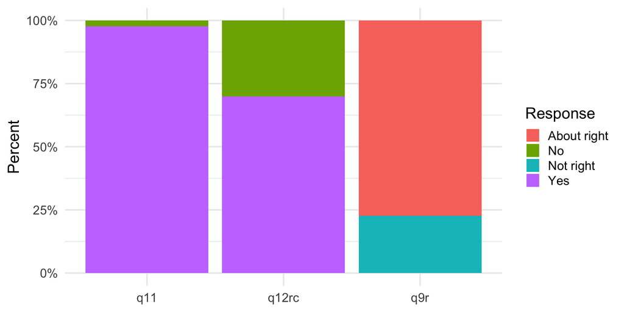

```r
case31 |>
  select(q9r, q11, q12rc) |>
  mutate(across(everything(), as.character)) |>
  pivot_longer(everything(), names_to = "item", values_to = "resp") |>
  filter(!is.na(resp)) |>
  ggplot(aes(item, fill = resp)) +
  geom_bar(position = "fill") +
  scale_y_continuous(labels = scales::percent) +
  labs(x = NULL, y = "Percent", fill = "Response")
```

## R6: Interval Items, One-Sample t-Tests

```r
bind_rows(
  tt(case31$q10r, 2.5, "q10r: Statement accuracy"),
  tt(case31$q31, 3, "q31: CU keeps information confidential"),
  tt(case31$q32, 3, "q32: CU loan processing is prompt"),
  tt(case31$q33, 3, "q33: CU meets members' needs"),
  tt(case31$q34, 3, "q34: CU loan applications are simple"),
  tt(case31$q37r, 3, "q37r: Overall rating")
) |>
  mutate(p = fmt_p(p)) |>
  kable(digits = 2)
```

| Item | n | Mean | SD | Test value | t | df | p | 95% CI |
| --- | --- | --- | --- | --- | --- | --- | --- | --- |
| q10r: Statement accuracy | 128 | 3.47 | 0.64 | 2.5 | 17.15 | 127 | < .001 | [3.36, 3.58] |
| q31: CU keeps information confidential | 128 | 3.95 | 0.68 | 3.0 | 15.74 | 127 | < .001 | [3.83, 4.06] |
| q32: CU loan processing is prompt | 128 | 3.72 | 0.79 | 3.0 | 10.25 | 127 | < .001 | [3.58, 3.86] |
| q33: CU meets members’ needs | 128 | 3.59 | 0.68 | 3.0 | 9.87 | 127 | < .001 | [3.47, 3.71] |
| q34: CU loan applications are simple | 128 | 3.46 | 0.78 | 3.0 | 6.66 | 127 | < .001 | [3.32, 3.60] |
| q37r: Overall rating | 121 | 4.07 | 0.73 | 3.0 | 16.13 | 120 | < .001 | [3.94, 4.20] |

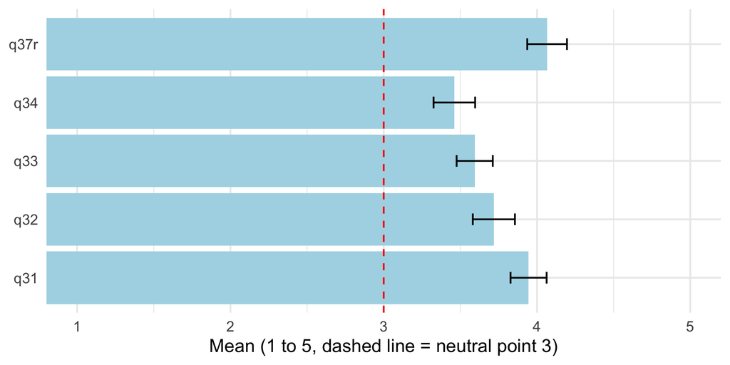

```r
case31 |>
  select(q31, q32, q33, q34, q37r) |>
  pivot_longer(everything(), names_to = "item", values_to = "value") |>
  group_by(item) |>
  summarise(mean = mean(value, na.rm = TRUE),
            se = sd(value, na.rm = TRUE) / sqrt(sum(!is.na(value)))) |>
  ggplot(aes(mean, item)) +
  geom_col(fill = "lightblue") +
  geom_errorbarh(aes(xmin = mean - 1.96 * se, xmax = mean + 1.96 * se), height = .2) +
  geom_vline(xintercept = 3, linetype = "dashed", color = "red") +
  coord_cartesian(xlim = c(1, 5)) +
  labs(x = "Mean (1 to 5, dashed line = neutral point 3)", y = NULL)
```

**Insights about R6**

- **Statements:** Most members (77%) say the frequency of statements is about right, almost all (98%) find them understandable, and the accuracy rating is above the midpoint (*M* = 3.47 of 4, *p* < .001).
- **Confidentiality:** 70% of members who answered say their accounts are kept confidential, and agreement that the credit union keeps information confidential is high (q31, *M* = 3.95).
- **Service and operations:** Members agree the credit union is prompt (q32, *M* = 3.72), meets their needs (q33, *M* = 3.59), and has simple loan applications (q34, *M* = 3.46). All are significantly above 3 (all *p* < .001).
- **Overall rating:** Members rate the credit union well overall (q37r, *M* = 4.07, *p* < .001).
- Operations are viewed favorably, so weak borrowing is probably not caused by how the credit union is run.

# Conclusion

## Summary

- **R1:** Savings rates are seen as average, so they are not a standout reason for joining.
- **R2:** Loan rates are also seen as average and not clearly lower than competitors’, which may push borrowers elsewhere.
- **R5:** Awareness is uneven across all 14 services. Many members know about loan products but have not used them, and many do not know about the basic share account.
- **R6:** Members view operations (statements, confidentiality, promptness, meeting needs, applications) and the credit union overall in a favorable light.
- **Recommendation:** Focus on promoting loan products and improving the rate message instead of fixing operations.

## Notes and Limits

- Chi-square goodness-of-fit tests for q9r, q11, and q12rc assume a 50/50 split under the null, which is a simple benchmark.
- Q2, Q28, and Q29 (direct reasons to join or borrow elsewhere) are not in the data file, so R1 and R2 use the available rate items.
- The sample has 128 respondents with some missing values (q7r 10, q8r 21, q37r 7).

## Appendix: Links

- **GitHub Pages:** [View my published report](https://dmcpp26.github.io/ibm6500-assignments/IC11-2-Case31/summary-analysis-case31-dmeza.html)
- **GitHub Repo:** dmcpp26/ibm6500-assignments